# Data transformation

### 5.2.4 Exercises

1. Find all flights that
   1. Had an arrival delay of two or more hours
   2. Flew to Houston (`IAH` or `HOU`)
   3. Were operated by United, American, or Delta
   4. Departed in summer (July, August, and September)
   5. Arrived more than two hours late, but didn’t leave late
   6. Were delayed by at least an hour, but made up over 30 minutes in flight
   7. Departed between midnight and 6am (inclusive)

Had an arrival delay of two or more hours:

```r
filter(flights, arr_delay >= 120)
```

```
## # A tibble: 10,200 x 19
##     year month   day dep_… sche… dep_… arr_… sche… arr_… carr… flig… tail…
##    <int> <int> <int> <int> <int> <dbl> <int> <int> <dbl> <chr> <int> <chr>
##  1  2013     1     1   811   630 101    1047   830   137 MQ     4576 N531…
##  2  2013     1     1   848  1835 853    1001  1950   851 MQ     3944 N942…
##  3  2013     1     1   957   733 144    1056   853   123 UA      856 N534…
##  4  2013     1     1  1114   900 134    1447  1222   145 UA     1086 N765…
##  5  2013     1     1  1505  1310 115    1638  1431   127 EV     4497 N179…
##  6  2013     1     1  1525  1340 105    1831  1626   125 B6      525 N231…
##  7  2013     1     1  1549  1445  64.0  1912  1656   136 EV     4181 N211…
##  8  2013     1     1  1558  1359 119    1718  1515   123 EV     5712 N826…
##  9  2013     1     1  1732  1630  62.0  2028  1825   123 EV     4092 N169…
## 10  2013     1     1  1803  1620 103    2008  1750   138 MQ     4622 N504…
## # ... with 10,190 more rows, and 7 more variables: origin <chr>, dest
## #   <chr>, air_time <dbl>, distance <dbl>, hour <dbl>, minute <dbl>,
## #   time_hour <dttm>
```

Flew to Houston (`IAH` or `HOU`):

```r
filter(flights, dest %in% c("IAH", "HOU"))
```

```
## # A tibble: 9,313 x 19
##     year month   day dep_t… sched… dep_de… arr_… sche… arr_de… carr… flig…
##    <int> <int> <int>  <int>  <int>   <dbl> <int> <int>   <dbl> <chr> <int>
##  1  2013     1     1    517    515    2.00   830   819   11.0  UA     1545
##  2  2013     1     1    533    529    4.00   850   830   20.0  UA     1714
##  3  2013     1     1    623    627 -  4.00   933   932    1.00 UA      496
##  4  2013     1     1    728    732 -  4.00  1041  1038    3.00 UA      473
##  5  2013     1     1    739    739    0     1104  1038   26.0  UA     1479
##  6  2013     1     1    908    908    0     1228  1219    9.00 UA     1220
##  7  2013     1     1   1028   1026    2.00  1350  1339   11.0  UA     1004
##  8  2013     1     1   1044   1045 -  1.00  1352  1351    1.00 UA      455
##  9  2013     1     1   1114    900  134     1447  1222  145    UA     1086
## 10  2013     1     1   1205   1200    5.00  1503  1505 -  2.00 UA     1461
## # ... with 9,303 more rows, and 8 more variables: tailnum <chr>, origin
## #   <chr>, dest <chr>, air_time <dbl>, distance <dbl>, hour <dbl>, minute
## #   <dbl>, time_hour <dttm>
```

Were operated by United, American, or Delta:

```r
filter(flights, carrier %in% c("UA", "AA", "DL"))
```

```
## # A tibble: 139,504 x 19
##     year month   day dep_t… sched_… dep_d… arr_… sched… arr_d… carr… flig…
##    <int> <int> <int>  <int>   <int>  <dbl> <int>  <int>  <dbl> <chr> <int>
##  1  2013     1     1    517     515   2.00   830    819  11.0  UA     1545
##  2  2013     1     1    533     529   4.00   850    830  20.0  UA     1714
##  3  2013     1     1    542     540   2.00   923    850  33.0  AA     1141
##  4  2013     1     1    554     600  -6.00   812    837 -25.0  DL      461
##  5  2013     1     1    554     558  -4.00   740    728  12.0  UA     1696
##  6  2013     1     1    558     600  -2.00   753    745   8.00 AA      301
##  7  2013     1     1    558     600  -2.00   924    917   7.00 UA      194
##  8  2013     1     1    558     600  -2.00   923    937 -14.0  UA     1124
##  9  2013     1     1    559     600  -1.00   941    910  31.0  AA      707
## 10  2013     1     1    559     600  -1.00   854    902 - 8.00 UA     1187
## # ... with 139,494 more rows, and 8 more variables: tailnum <chr>, origin
## #   <chr>, dest <chr>, air_time <dbl>, distance <dbl>, hour <dbl>, minute
## #   <dbl>, time_hour <dttm>
```

(To find the two letter carrier abbreviations, see `airlines`.)

Departed in summer (July, August, and September):

```r
filter(flights, month %in% c(7, 8, 9))
```

```
## # A tibble: 86,326 x 19
##     year month   day dep_t… sched_… dep_de… arr_… sched… arr_… carr… flig…
##    <int> <int> <int>  <int>   <int>   <dbl> <int>  <int> <dbl> <chr> <int>
##  1  2013     7     1      1    2029  212      236   2359   157 B6      915
##  2  2013     7     1      2    2359    3.00   344    344     0 B6     1503
##  3  2013     7     1     29    2245  104      151      1   110 B6      234
##  4  2013     7     1     43    2130  193      322     14   188 B6     1371
##  5  2013     7     1     44    2150  174      300    100   120 AA      185
##  6  2013     7     1     46    2051  235      304   2358   186 B6      165
##  7  2013     7     1     48    2001  287      308   2305   243 VX      415
##  8  2013     7     1     58    2155  183      335     43   172 B6      425
##  9  2013     7     1    100    2146  194      327     30   177 B6     1183
## 10  2013     7     1    100    2245  135      337    135   122 B6      623
## # ... with 86,316 more rows, and 8 more variables: tailnum <chr>, origin
## #   <chr>, dest <chr>, air_time <dbl>, distance <dbl>, hour <dbl>, minute
## #   <dbl>, time_hour <dttm>
```

Arrived more than two hours late, but didn’t leave late:

```r
filter(flights, arr_delay >= 120 & dep_delay <= 0)
```

```
## # A tibble: 29 x 19
##     year month   day dep_… sche… dep_… arr_… sche… arr_… carr… flig… tail…
##    <int> <int> <int> <int> <int> <dbl> <int> <int> <dbl> <chr> <int> <chr>
##  1  2013     1    27  1419  1420 -1.00  1754  1550   124 MQ     3728 N1EA…
##  2  2013    10     7  1350  1350  0     1736  1526   130 EV     5181 N611…
##  3  2013    10     7  1357  1359 -2.00  1858  1654   124 AA     1151 N3CM…
##  4  2013    10    16   657   700 -3.00  1258  1056   122 B6        3 N703…
##  5  2013    11     1   658   700 -2.00  1329  1015   194 VX      399 N629…
##  6  2013     3    18  1844  1847 -3.00    39  2219   140 UA      389 N560…
##  7  2013     4    17  1635  1640 -5.00  2049  1845   124 MQ     4540 N721…
##  8  2013     4    18   558   600 -2.00  1149   850   179 AA      707 N3EX…
##  9  2013     4    18   655   700 -5.00  1213   950   143 AA     2083 N565…
## 10  2013     5    22  1827  1830 -3.00  2217  2010   127 MQ     4674 N518…
## # ... with 19 more rows, and 7 more variables: origin <chr>, dest <chr>,
## #   air_time <dbl>, distance <dbl>, hour <dbl>, minute <dbl>, time_hour
## #   <dttm>
```

Were delayed by at least an hour, but made up over 30 minutes in flight:

```r
filter(flights, dep_delay >= 60  & dep_delay - arr_delay > 30)
```

```
## # A tibble: 1,844 x 19
##     year month   day dep_t… sched_… dep_d… arr_… sched… arr_d… carr… flig…
##    <int> <int> <int>  <int>   <int>  <dbl> <int>  <int>  <dbl> <chr> <int>
##  1  2013     1     1   2205    1720  285      46   2040 246    AA     1999
##  2  2013     1     1   2326    2130  116     131     18  73.0  B6      199
##  3  2013     1     3   1503    1221  162    1803   1555 128    UA      551
##  4  2013     1     3   1839    1700   99.0  2056   1950  66.0  AA      575
##  5  2013     1     3   1850    1745   65.0  2148   2120  28.0  AA      177
##  6  2013     1     3   1941    1759  102    2246   2139  67.0  UA      979
##  7  2013     1     3   1950    1845   65.0  2228   2227   1.00 B6       91
##  8  2013     1     3   2015    1915   60.0  2135   2111  24.0  9E     3525
##  9  2013     1     3   2257    2000  177      45   2224 141    9E     3439
## 10  2013     1     4   1917    1700  137    2135   1950 105    AA      575
## # ... with 1,834 more rows, and 8 more variables: tailnum <chr>, origin
## #   <chr>, dest <chr>, air_time <dbl>, distance <dbl>, hour <dbl>, minute
## #   <dbl>, time_hour <dttm>
```

Departed between midnight and 6am (inclusive):

```r
filter(flights, dep_time <= 600 | dep_time == 2400)
```

```
## # A tibble: 9,373 x 19
##     year month   day dep_t… sched_… dep_d… arr_… sched… arr_d… carr… flig…
##    <int> <int> <int>  <int>   <int>  <dbl> <int>  <int>  <dbl> <chr> <int>
##  1  2013     1     1    517     515   2.00   830    819  11.0  UA     1545
##  2  2013     1     1    533     529   4.00   850    830  20.0  UA     1714
##  3  2013     1     1    542     540   2.00   923    850  33.0  AA     1141
##  4  2013     1     1    544     545  -1.00  1004   1022 -18.0  B6      725
##  5  2013     1     1    554     600  -6.00   812    837 -25.0  DL      461
##  6  2013     1     1    554     558  -4.00   740    728  12.0  UA     1696
##  7  2013     1     1    555     600  -5.00   913    854  19.0  B6      507
##  8  2013     1     1    557     600  -3.00   709    723 -14.0  EV     5708
##  9  2013     1     1    557     600  -3.00   838    846 - 8.00 B6       79
## 10  2013     1     1    558     600  -2.00   753    745   8.00 AA      301
## # ... with 9,363 more rows, and 8 more variables: tailnum <chr>, origin
## #   <chr>, dest <chr>, air_time <dbl>, distance <dbl>, hour <dbl>, minute
## #   <dbl>, time_hour <dttm>
```

2. Another useful dplyr filtering helper is `between()`. What does it do? Can you use it to simplify the code needed to answer the previous challenges?

It is a shortcut for finding values that fall within a specified range:

```r
filter(flights, between(month, 7, 9))
```

```
## # A tibble: 86,326 x 19
##     year month   day dep_t… sched_… dep_de… arr_… sched… arr_… carr… flig…
##    <int> <int> <int>  <int>   <int>   <dbl> <int>  <int> <dbl> <chr> <int>
##  1  2013     7     1      1    2029  212      236   2359   157 B6      915
##  2  2013     7     1      2    2359    3.00   344    344     0 B6     1503
##  3  2013     7     1     29    2245  104      151      1   110 B6      234
##  4  2013     7     1     43    2130  193      322     14   188 B6     1371
##  5  2013     7     1     44    2150  174      300    100   120 AA      185
##  6  2013     7     1     46    2051  235      304   2358   186 B6      165
##  7  2013     7     1     48    2001  287      308   2305   243 VX      415
##  8  2013     7     1     58    2155  183      335     43   172 B6      425
##  9  2013     7     1    100    2146  194      327     30   177 B6     1183
## 10  2013     7     1    100    2245  135      337    135   122 B6      623
## # ... with 86,316 more rows, and 8 more variables: tailnum <chr>, origin
## #   <chr>, dest <chr>, air_time <dbl>, distance <dbl>, hour <dbl>, minute
## #   <dbl>, time_hour <dttm>
```

3. How many flights have a missing `dep_time`? What other variables are missing? What might these rows represent?

```r
filter(flights, is.na(dep_time))
```

```
## # A tibble: 8,255 x 19
##     year month   day dep_… sche… dep_… arr_… sche… arr_… carr… flig… tail…
##    <int> <int> <int> <int> <int> <dbl> <int> <int> <dbl> <chr> <int> <chr>
##  1  2013     1     1    NA  1630    NA    NA  1815    NA EV     4308 N181…
##  2  2013     1     1    NA  1935    NA    NA  2240    NA AA      791 N3EH…
##  3  2013     1     1    NA  1500    NA    NA  1825    NA AA     1925 N3EV…
##  4  2013     1     1    NA   600    NA    NA   901    NA B6      125 N618…
##  5  2013     1     2    NA  1540    NA    NA  1747    NA EV     4352 N105…
##  6  2013     1     2    NA  1620    NA    NA  1746    NA EV     4406 N139…
##  7  2013     1     2    NA  1355    NA    NA  1459    NA EV     4434 N105…
##  8  2013     1     2    NA  1420    NA    NA  1644    NA EV     4935 N759…
##  9  2013     1     2    NA  1321    NA    NA  1536    NA EV     3849 N135…
## 10  2013     1     2    NA  1545    NA    NA  1910    NA AA      133 <NA>
## # ... with 8,245 more rows, and 7 more variables: origin <chr>, dest
## #   <chr>, air_time <dbl>, distance <dbl>, hour <dbl>, minute <dbl>,
## #   time_hour <dttm>
```

8,255 flights.

To see what other variables are missing, you can use `View()`:

```r
View(filter(flights, is.na(dep_time)))
```

`dep_delay`, `arr_time`, `arr_delay`, and `air_time` are also missing. These flights were most likely cancelled.

4. Why is `NA ^ 0` not missing? Why is `NA | TRUE` not missing? Why is `FALSE & NA` not missing? Can you figure out the general rule? (`NA * 0` is a tricky counterexample!)

See Jeffrey Arnold’s [explanation](https://jrnold.github.io/r4ds-exercise-solutions/data-transformation.html#filter).

### 5.3.1 Exercises

1. How could you use `arrange()` to sort all missing values to the start? (Hint: use `is.na()`).

```r
arrange(flights, desc(is.na(dep_time)))
```

```
## # A tibble: 336,776 x 19
##     year month   day dep_… sche… dep_… arr_… sche… arr_… carr… flig… tail…
##    <int> <int> <int> <int> <int> <dbl> <int> <int> <dbl> <chr> <int> <chr>
##  1  2013     1     1    NA  1630    NA    NA  1815    NA EV     4308 N181…
##  2  2013     1     1    NA  1935    NA    NA  2240    NA AA      791 N3EH…
##  3  2013     1     1    NA  1500    NA    NA  1825    NA AA     1925 N3EV…
##  4  2013     1     1    NA   600    NA    NA   901    NA B6      125 N618…
##  5  2013     1     2    NA  1540    NA    NA  1747    NA EV     4352 N105…
##  6  2013     1     2    NA  1620    NA    NA  1746    NA EV     4406 N139…
##  7  2013     1     2    NA  1355    NA    NA  1459    NA EV     4434 N105…
##  8  2013     1     2    NA  1420    NA    NA  1644    NA EV     4935 N759…
##  9  2013     1     2    NA  1321    NA    NA  1536    NA EV     3849 N135…
## 10  2013     1     2    NA  1545    NA    NA  1910    NA AA      133 <NA>
## # ... with 336,766 more rows, and 7 more variables: origin <chr>, dest
## #   <chr>, air_time <dbl>, distance <dbl>, hour <dbl>, minute <dbl>,
## #   time_hour <dttm>
```

2. Sort `flights` to find the most delayed flights. Find the flights that left earliest.

```r
arrange(flights, desc(dep_delay))
```

```
## # A tibble: 336,776 x 19
##     year month   day dep_… sche… dep_… arr_… sche… arr_… carr… flig… tail…
##    <int> <int> <int> <int> <int> <dbl> <int> <int> <dbl> <chr> <int> <chr>
##  1  2013     1     9   641   900  1301  1242  1530  1272 HA       51 N384…
##  2  2013     6    15  1432  1935  1137  1607  2120  1127 MQ     3535 N504…
##  3  2013     1    10  1121  1635  1126  1239  1810  1109 MQ     3695 N517…
##  4  2013     9    20  1139  1845  1014  1457  2210  1007 AA      177 N338…
##  5  2013     7    22   845  1600  1005  1044  1815   989 MQ     3075 N665…
##  6  2013     4    10  1100  1900   960  1342  2211   931 DL     2391 N959…
##  7  2013     3    17  2321   810   911   135  1020   915 DL     2119 N927…
##  8  2013     6    27   959  1900   899  1236  2226   850 DL     2007 N376…
##  9  2013     7    22  2257   759   898   121  1026   895 DL     2047 N671…
## 10  2013    12     5   756  1700   896  1058  2020   878 AA      172 N5DM…
## # ... with 336,766 more rows, and 7 more variables: origin <chr>, dest
## #   <chr>, air_time <dbl>, distance <dbl>, hour <dbl>, minute <dbl>,
## #   time_hour <dttm>
```

```r
arrange(flights, dep_delay)
```

```
## # A tibble: 336,776 x 19
##     year month   day dep_t… sched_… dep_d… arr_… sched… arr_d… carr… flig…
##    <int> <int> <int>  <int>   <int>  <dbl> <int>  <int>  <dbl> <chr> <int>
##  1  2013    12     7   2040    2123  -43.0    40   2352  48.0  B6       97
##  2  2013     2     3   2022    2055  -33.0  2240   2338 -58.0  DL     1715
##  3  2013    11    10   1408    1440  -32.0  1549   1559 -10.0  EV     5713
##  4  2013     1    11   1900    1930  -30.0  2233   2243 -10.0  DL     1435
##  5  2013     1    29   1703    1730  -27.0  1947   1957 -10.0  F9      837
##  6  2013     8     9    729     755  -26.0  1002    955   7.00 MQ     3478
##  7  2013    10    23   1907    1932  -25.0  2143   2143   0    EV     4361
##  8  2013     3    30   2030    2055  -25.0  2213   2250 -37.0  MQ     4573
##  9  2013     3     2   1431    1455  -24.0  1601   1631 -30.0  9E     3318
## 10  2013     5     5    934     958  -24.0  1225   1309 -44.0  B6      375
## # ... with 336,766 more rows, and 8 more variables: tailnum <chr>, origin
## #   <chr>, dest <chr>, air_time <dbl>, distance <dbl>, hour <dbl>, minute
## #   <dbl>, time_hour <dttm>
```

3. Sort `flights` to find the fastest flights.

This depends how you define “fastest flights”. It could refer to the least amount of `air_time`:

```r
arrange(flights, air_time)
```

```
## # A tibble: 336,776 x 19
##     year month   day dep_t… sched_… dep_d… arr_… sched… arr_d… carr… flig…
##    <int> <int> <int>  <int>   <int>  <dbl> <int>  <int>  <dbl> <chr> <int>
##  1  2013     1    16   1355    1315  40.0   1442   1411  31.0  EV     4368
##  2  2013     4    13    537     527  10.0    622    628 - 6.00 EV     4631
##  3  2013    12     6    922     851  31.0   1021    954  27.0  EV     4276
##  4  2013     2     3   2153    2129  24.0   2247   2224  23.0  EV     4619
##  5  2013     2     5   1303    1315 -12.0   1342   1411 -29.0  EV     4368
##  6  2013     2    12   2123    2130 - 7.00  2211   2225 -14.0  EV     4619
##  7  2013     3     2   1450    1500 -10.0   1547   1608 -21.0  US     2132
##  8  2013     3     8   2026    1935  51.0   2131   2056  35.0  9E     3650
##  9  2013     3    18   1456    1329  87.0   1533   1426  67.0  EV     4118
## 10  2013     3    19   2226    2145  41.0   2305   2246  19.0  EV     4276
## # ... with 336,766 more rows, and 8 more variables: tailnum <chr>, origin
## #   <chr>, dest <chr>, air_time <dbl>, distance <dbl>, hour <dbl>, minute
## #   <dbl>, time_hour <dttm>
```

4. Which flights travelled the longest? Which travelled the shortest?

If we assume this refers to distance travelled:

```r
arrange(flights, desc(distance))
```

```
## # A tibble: 336,776 x 19
##     year month   day dep_t… sched… dep_de… arr_… sche… arr_de… carr… flig…
##    <int> <int> <int>  <int>  <int>   <dbl> <int> <int>   <dbl> <chr> <int>
##  1  2013     1     1    857    900 -3.00e⁰  1516  1530 -1.40e¹ HA       51
##  2  2013     1     2    909    900  9.00e⁰  1525  1530 -5.00e⁰ HA       51
##  3  2013     1     3    914    900  1.40e¹  1504  1530 -2.60e¹ HA       51
##  4  2013     1     4    900    900  0       1516  1530 -1.40e¹ HA       51
##  5  2013     1     5    858    900 -2.00e⁰  1519  1530 -1.10e¹ HA       51
##  6  2013     1     6   1019    900  7.90e¹  1558  1530  2.80e¹ HA       51
##  7  2013     1     7   1042    900  1.02e²  1620  1530  5.00e¹ HA       51
##  8  2013     1     8    901    900  1.00e⁰  1504  1530 -2.60e¹ HA       51
##  9  2013     1     9    641    900  1.30e³  1242  1530  1.27e³ HA       51
## 10  2013     1    10    859    900 -1.00e⁰  1449  1530 -4.10e¹ HA       51
## # ... with 336,766 more rows, and 8 more variables: tailnum <chr>, origin
## #   <chr>, dest <chr>, air_time <dbl>, distance <dbl>, hour <dbl>, minute
## #   <dbl>, time_hour <dttm>
```

The longest flight is from JFK to HNL (Honolulu) at 4983 miles.

```r
arrange(flights, distance)
```

```
## # A tibble: 336,776 x 19
##     year month   day dep_t… sched… dep_de… arr_… sche… arr_de… carr… flig…
##    <int> <int> <int>  <int>  <int>   <dbl> <int> <int>   <dbl> <chr> <int>
##  1  2013     7    27     NA    106   NA       NA   245   NA    US     1632
##  2  2013     1     3   2127   2129 -  2.00  2222  2224 -  2.00 EV     3833
##  3  2013     1     4   1240   1200   40.0   1333  1306   27.0  EV     4193
##  4  2013     1     4   1829   1615  134     1937  1721  136    EV     4502
##  5  2013     1     4   2128   2129 -  1.00  2218  2224 -  6.00 EV     4645
##  6  2013     1     5   1155   1200 -  5.00  1241  1306 - 25.0  EV     4193
##  7  2013     1     6   2125   2129 -  4.00  2224  2224    0    EV     4619
##  8  2013     1     7   2124   2129 -  5.00  2212  2224 - 12.0  EV     4619
##  9  2013     1     8   2127   2130 -  3.00  2304  2225   39.0  EV     4619
## 10  2013     1     9   2126   2129 -  3.00  2217  2224 -  7.00 EV     4619
## # ... with 336,766 more rows, and 8 more variables: tailnum <chr>, origin
## #   <chr>, dest <chr>, air_time <dbl>, distance <dbl>, hour <dbl>, minute
## #   <dbl>, time_hour <dttm>
```

The shortest flight is from EWR (Newark) to LGA (La Guardia) at 17 miles, however this appears to be a cancelled flight (a number of variables such as `dep_time` are missing). The next shortest flight is from EWR to PHL (Philadelphia) at 80 miles.

(See `airports` to find the names that correspond to the FAA airport code.)

### 5.4.1 Exercises

1. Brainstorm as many ways as possible to select `dep_time`, `dep_delay`, `arr_time`, and `arr_delay` from `flights`.

```r
select(flights, dep_time, dep_delay, arr_time, arr_delay)
```

```
## # A tibble: 336,776 x 4
##    dep_time dep_delay arr_time arr_delay
##       <int>     <dbl>    <int>     <dbl>
##  1      517      2.00      830     11.0
##  2      533      4.00      850     20.0
##  3      542      2.00      923     33.0
##  4      544     -1.00     1004    -18.0
##  5      554     -6.00      812    -25.0
##  6      554     -4.00      740     12.0
##  7      555     -5.00      913     19.0
##  8      557     -3.00      709    -14.0
##  9      557     -3.00      838    - 8.00
## 10      558     -2.00      753      8.00
## # ... with 336,766 more rows
```

```r
select(flights, starts_with("dep"), starts_with("arr"))
```

```
## # A tibble: 336,776 x 4
##    dep_time dep_delay arr_time arr_delay
##       <int>     <dbl>    <int>     <dbl>
##  1      517      2.00      830     11.0
##  2      533      4.00      850     20.0
##  3      542      2.00      923     33.0
##  4      544     -1.00     1004    -18.0
##  5      554     -6.00      812    -25.0
##  6      554     -4.00      740     12.0
##  7      555     -5.00      913     19.0
##  8      557     -3.00      709    -14.0
##  9      557     -3.00      838    - 8.00
## 10      558     -2.00      753      8.00
## # ... with 336,766 more rows
```

2. What happens if you include the name of a variable multiple times in a `select()` call?

It will only print once.

```r
select(flights, dep_time, dep_time)
```

```
## # A tibble: 336,776 x 1
##    dep_time
##       <int>
##  1      517
##  2      533
##  3      542
##  4      544
##  5      554
##  6      554
##  7      555
##  8      557
##  9      557
## 10      558
## # ... with 336,766 more rows
```

3. What does the `one_of()` function do? Why might it be helpful in conjunction with this vector?

```r
vars <- c("year", "month", "day", "dep_delay", "arr_delay")
```

The `one_of()` function allows you to use variables stored in a character vector:

```r
select(flights, one_of(vars))
```

```
## # A tibble: 336,776 x 5
##     year month   day dep_delay arr_delay
##    <int> <int> <int>     <dbl>     <dbl>
##  1  2013     1     1      2.00     11.0
##  2  2013     1     1      4.00     20.0
##  3  2013     1     1      2.00     33.0
##  4  2013     1     1     -1.00    -18.0
##  5  2013     1     1     -6.00    -25.0
##  6  2013     1     1     -4.00     12.0
##  7  2013     1     1     -5.00     19.0
##  8  2013     1     1     -3.00    -14.0
##  9  2013     1     1     -3.00    - 8.00
## 10  2013     1     1     -2.00      8.00
## # ... with 336,766 more rows
```

It improves the readability of code.

4. Does the result of running the following code surprise you? How do the select helpers deal with case by default? How can you change that default?

```r
select(flights, contains("TIME"))
```

```
## # A tibble: 336,776 x 6
##    dep_time sched_dep_time arr_time sched_arr_… air_t… time_hour
##       <int>          <int>    <int>       <int>  <dbl> <dttm>
##  1      517            515      830         819  227   2013-01-01 05:00:00
##  2      533            529      850         830  227   2013-01-01 05:00:00
##  3      542            540      923         850  160   2013-01-01 05:00:00
##  4      544            545     1004        1022  183   2013-01-01 05:00:00
##  5      554            600      812         837  116   2013-01-01 06:00:00
##  6      554            558      740         728  150   2013-01-01 05:00:00
##  7      555            600      913         854  158   2013-01-01 06:00:00
##  8      557            600      709         723   53.0 2013-01-01 06:00:00
##  9      557            600      838         846  140   2013-01-01 06:00:00
## 10      558            600      753         745  138   2013-01-01 06:00:00
## # ... with 336,766 more rows
```

Select helpers are not case sensitive by default. To change the default, use `ignore.case = FALSE`.

### 5.5.2 Exercises

1. Currently `dep_time` and `sched_dep_time` are convenient to look at, but hard to compute with because they’re not really continuous numbers. Convert them to a more convenient representation of number of minutes since midnight.

```r
transmute(flights,
  dep_time,
  hour = dep_time %/% 100,
  minute = dep_time %% 100,
  dep_time_mins = (hour * 60) + minute
)
```

```
## # A tibble: 336,776 x 4
##    dep_time  hour minute dep_time_mins
##       <int> <dbl>  <dbl>         <dbl>
##  1      517  5.00   17.0           317
##  2      533  5.00   33.0           333
##  3      542  5.00   42.0           342
##  4      544  5.00   44.0           344
##  5      554  5.00   54.0           354
##  6      554  5.00   54.0           354
##  7      555  5.00   55.0           355
##  8      557  5.00   57.0           357
##  9      557  5.00   57.0           357
## 10      558  5.00   58.0           358
## # ... with 336,766 more rows
```

```r
transmute(flights,
  sched_dep_time,
  hour = sched_dep_time %/% 100,
  minute = sched_dep_time %% 100,
  sched_dep_mins = (hour * 60) + minute
)
```

```
## # A tibble: 336,776 x 4
##    sched_dep_time  hour minute sched_dep_mins
##             <int> <dbl>  <dbl>          <dbl>
##  1            515  5.00   15.0            315
##  2            529  5.00   29.0            329
##  3            540  5.00   40.0            340
##  4            545  5.00   45.0            345
##  5            600  6.00    0              360
##  6            558  5.00   58.0            358
##  7            600  6.00    0              360
##  8            600  6.00    0              360
##  9            600  6.00    0              360
## 10            600  6.00    0              360
## # ... with 336,766 more rows
```

2. Compare `air_time` with `arr_time - dep_time`. What do you expect to see? What do you see? What do you need to do to fix it?

```r
transmute(flights, air_time, arr_time - dep_time)
```

```
## # A tibble: 336,776 x 2
##    air_time `arr_time - dep_time`
##       <dbl>                 <int>
##  1    227                     313
##  2    227                     317
##  3    160                     381
##  4    183                     460
##  5    116                     258
##  6    150                     186
##  7    158                     358
##  8     53.0                   152
##  9    140                     281
## 10    138                     195
## # ... with 336,766 more rows
```

You would expect `arr_time - dep_time == air_time`. This discrepancy is explained by timezone differences. `arr_time` and `dep_time` are in local timezones that may differ.

3. Compare `dep_time`, `sched_dep_time`, and `dep_delay`. How would you expect those three numbers to be related?

```r
select(flights, dep_time, sched_dep_time, dep_delay)
```

```
## # A tibble: 336,776 x 3
##    dep_time sched_dep_time dep_delay
##       <int>          <int>     <dbl>
##  1      517            515      2.00
##  2      533            529      4.00
##  3      542            540      2.00
##  4      544            545     -1.00
##  5      554            600     -6.00
##  6      554            558     -4.00
##  7      555            600     -5.00
##  8      557            600     -3.00
##  9      557            600     -3.00
## 10      558            600     -2.00
## # ... with 336,766 more rows
```

`dep_time - sched_dep_time == dep_delay`.

4. Find the 10 most delayed flights using a ranking function. How do you want to handle ties? Carefully read the documentation for `min_rank()`.

```r
flights_ranked <- mutate(flights, rank = min_rank(-dep_delay))
arrange(flights_ranked, desc(dep_delay))
```

```
## # A tibble: 336,776 x 20
##     year month   day dep_… sche… dep_… arr_… sche… arr_… carr… flig… tail…
##    <int> <int> <int> <int> <int> <dbl> <int> <int> <dbl> <chr> <int> <chr>
##  1  2013     1     9   641   900  1301  1242  1530  1272 HA       51 N384…
##  2  2013     6    15  1432  1935  1137  1607  2120  1127 MQ     3535 N504…
##  3  2013     1    10  1121  1635  1126  1239  1810  1109 MQ     3695 N517…
##  4  2013     9    20  1139  1845  1014  1457  2210  1007 AA      177 N338…
##  5  2013     7    22   845  1600  1005  1044  1815   989 MQ     3075 N665…
##  6  2013     4    10  1100  1900   960  1342  2211   931 DL     2391 N959…
##  7  2013     3    17  2321   810   911   135  1020   915 DL     2119 N927…
##  8  2013     6    27   959  1900   899  1236  2226   850 DL     2007 N376…
##  9  2013     7    22  2257   759   898   121  1026   895 DL     2047 N671…
## 10  2013    12     5   756  1700   896  1058  2020   878 AA      172 N5DM…
## # ... with 336,766 more rows, and 8 more variables: origin <chr>, dest
## #   <chr>, air_time <dbl>, distance <dbl>, hour <dbl>, minute <dbl>,
## #   time_hour <dttm>, rank <int>
```

Ties should be assigned the lowest rank. `ties.method = "min"` is the default for `min_rank()`.

5. What does `1:3 + 1:10` return? Why?

```r
1:3 + 1:10
```

```
##  [1]  2  4  6  5  7  9  8 10 12 11
```

1 + 1 = 2; 2 + 2 = 4; 3 + 3 = 6; 4 + 1 = 5; 5 + 2 = 7, and so on.

6. What trigonometric functions does R provide?

Cosine, sine, tangent, arc-cosine, and more. See `?Trig`.

### 5.6.7 Exercises

1. Brainstorm at least 5 different ways to assess the typical delay characteristics of a group of flights. Consider the following scenarios:
   - A flight is 15 minutes early 50% of the time, and 15 minutes late 50% of the time.
   - A flight is always 10 minutes late.
   - A flight is 30 minutes early 50% of the time, and 30 minutes late 50% of the time.
   - 99% of the time a flight is on time. 1% of the time it’s 2 hours late.

Which is more important: arrival delay or departure delay?

```r
flights %>%
  group_by(flight, origin, dest) %>%
  filter(arr_delay == 10) %>%
  summarise()
```

```
## # A tibble: 1,877 x 3
## # Groups: flight, origin [?]
##    flight origin dest
##     <int> <chr>  <chr>
##  1      1 JFK    FLL
##  2      3 EWR    DEN
##  3      3 JFK    LAX
##  4      3 JFK    SJU
##  5      3 LGA    MDW
##  6      4 JFK    BUF
##  7      4 JFK    SJU
##  8      5 EWR    FLL
##  9      5 EWR    SEA
## 10      6 JFK    BUF
## # ... with 1,867 more rows
```

```r
flights %>%
  group_by(flight, origin, dest) %>%
  summarise(avg_arr_delay = mean(arr_delay, na.rm = TRUE), count = n()) %>%
  filter(avg_arr_delay == 10)
```

```
## # A tibble: 65 x 5
## # Groups: flight, origin [64]
##    flight origin dest  avg_arr_delay count
##     <int> <chr>  <chr>         <dbl> <int>
##  1      3 EWR    DEN            10.0    23
##  2    102 LGA    MKE            10.0     1
##  3    171 EWR    DEN            10.0     5
##  4    252 EWR    RSW            10.0     2
##  5    265 EWR    FLL            10.0     2
##  6    271 EWR    TPA            10.0     1
##  7    279 LGA    IAH            10.0     1
##  8    299 EWR    PHX            10.0     4
##  9    316 EWR    SFO            10.0     1
## 10    363 EWR    DFW            10.0     1
## # ... with 55 more rows
```

Departure delay is probably more important for travellers.

2. Come up with another approach that will give you the same output as `not_cancelled %>% count(dest)` and `not_cancelled %>% count(tailnum, wt = distance)` (without using `count()`).

```r
not_cancelled %>%
  group_by(dest) %>%
  summarise(count = n())
```

```
## # A tibble: 104 x 2
##    dest  count
##    <chr> <int>
##  1 ABQ     254
##  2 ACK     264
##  3 ALB     418
##  4 ANC       8
##  5 ATL   16837
##  6 AUS    2411
##  7 AVL     261
##  8 BDL     412
##  9 BGR     358
## 10 BHM     269
## # ... with 94 more rows
```

```r
not_cancelled %>%
  group_by(tailnum) %>%
  summarise(distance_total = sum(distance))
```

```
## # A tibble: 4,037 x 2
##    tailnum distance_total
##    <chr>            <dbl>
##  1 D942DN            3418
##  2 N0EGMQ          239143
##  3 N10156          109664
##  4 N102UW           25722
##  5 N103US           24619
##  6 N104UW           24616
##  7 N10575          139903
##  8 N105UW           23618
##  9 N107US           21677
## 10 N108UW           32070
## # ... with 4,027 more rows
```

3. Our definition of cancelled flights (`is.na(dep_delay) | is.na(arr_delay)`) is slightly suboptimal. Why? Which is the most important column?

Flights that do no depart cannot arrive at any location. However, flights that depart but are `NA` for `arr_delay` may have redirected or crashed.

The importance of the column depends on the question being answered. `dep_delay` is probably more representative of cancelled flights for the above reason.

4. Look at the number of cancelled flights per day. Is there a pattern? Is the proportion of cancelled flights related to the average delay?

```r
flights %>%
  group_by(month, day) %>%
  summarise(cancelled = sum(is.na(dep_delay)))
```

```
## # A tibble: 365 x 3
## # Groups: month [?]
##    month   day cancelled
##    <int> <int>     <int>
##  1     1     1         4
##  2     1     2         8
##  3     1     3        10
##  4     1     4         6
##  5     1     5         3
##  6     1     6         1
##  7     1     7         3
##  8     1     8         4
##  9     1     9         5
## 10     1    10         3
## # ... with 355 more rows
```

It is difficult to tell just from this output. Let’s visualise this instead:

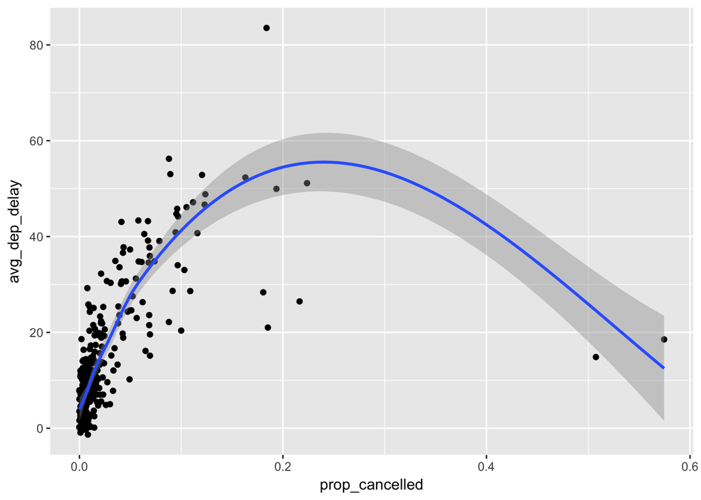

```r
flights %>%
  mutate(cancelled = is.na(dep_delay)) %>%
  group_by(month, day) %>%
  summarise(
    prop_cancelled = mean(cancelled),
    avg_dep_delay = mean(dep_delay, na.rm = TRUE)
  ) %>%
  ggplot(aes(x = prop_cancelled, y = avg_dep_delay)) +
    geom_point() +
    geom_smooth(se = TRUE)
```

There is a positive relationship between the proportion of cancelled flights and average delay. However, there are a few exceptional days with a high number of cancelled flights and relatively low average delay. If I had to guess, this might be related to bad weather (i.e., all flights were cancelled for a specific time period, so `avg_dep_delay` was close to zero).

5. Which carrier has the worst delays? Challenge: can you disentangle the effects of bad airports vs. bad carriers? Why/why not? (Hint: think about `flights %>% group_by(carrier, dest) %>% summarise(n())`)

Frontier Airlines (F9) has the worst delays:

```r
not_cancelled %>%
  group_by(carrier) %>%
  summarise(avg_delay = mean(dep_delay, na.rm = TRUE)) %>%
  arrange(desc(avg_delay))
```

```
## # A tibble: 16 x 2
##    carrier avg_delay
##    <chr>       <dbl>
##  1 F9          20.2
##  2 EV          19.8
##  3 YV          18.9
##  4 FL          18.6
##  5 WN          17.7
##  6 9E          16.4
##  7 B6          13.0
##  8 VX          12.8
##  9 OO          12.6
## 10 UA          12.0
## 11 MQ          10.4
## 12 DL           9.22
## 13 AA           8.57
## 14 AS           5.83
## 15 HA           4.90
## 16 US           3.74
```

You cannot disentangle the effects of bad airports vs. bad carriers because there is an uneven distribution in destinations by carrier. Some carriers might operate more frequently from bad airports and vice versa.

6. What does the `sort` argument to `count()` do. When might you use it?

`sort = TRUE` will sort output in descending order of `n`. You can use it for ranking instead of using `min_rank()` and/or `arrange()`.

```r
not_cancelled %>% count(dest, sort = TRUE)
```

```
## # A tibble: 104 x 2
##    dest      n
##    <chr> <int>
##  1 ATL   16837
##  2 ORD   16566
##  3 LAX   16026
##  4 BOS   15022
##  5 MCO   13967
##  6 CLT   13674
##  7 SFO   13173
##  8 FLL   11897
##  9 MIA   11593
## 10 DCA    9111
## # ... with 94 more rows
```

### 5.7.1 Exercises

1. Refer back to the lists of useful mutate and filtering functions. Describe how each operation changes when you combine it with grouping.

When combined with grouping, functions operate within groups only, not the entire dataset. For example:

```r
# What is the mean air time for each carrier?
flights %>%
  group_by(carrier) %>%
  summarise(mean_air_time = mean(air_time, na.rm = TRUE))
```

```
## # A tibble: 16 x 2
##    carrier mean_air_time
##    <chr>           <dbl>
##  1 9E               86.8
##  2 AA              189
##  3 AS              326
##  4 B6              151
##  5 DL              174
##  6 EV               90.1
##  7 F9              230
##  8 FL              101
##  9 HA              623
## 10 MQ               91.2
## 11 OO               83.5
## 12 UA              212
## 13 US               88.6
## 14 VX              337
## 15 WN              148
## 16 YV               65.7
```

```r
# What is the mean arrival delay for each month excluding all flights that were not delayed?
flights %>%
  filter(arr_delay > 0) %>%
  group_by(month) %>%
  summarise(avg_arr_delay = mean(arr_delay))
```

```
## # A tibble: 12 x 2
##    month avg_arr_delay
##    <int>         <dbl>
##  1     1          34.5
##  2     2          33.7
##  3     3          40.6
##  4     4          42.7
##  5     5          41.9
##  6     6          53.7
##  7     7          54.0
##  8     8          39.5
##  9     9          38.8
## 10    10          29.0
## 11    11          27.5
## 12    12          39.7
```

2. Which plane (`tailnum`) has the worst on-time record?

N844MH.

```r
flights %>%
  group_by(tailnum) %>%
  summarise(avg_delay = mean(arr_delay, na.rm = TRUE)) %>%
  arrange(desc(avg_delay))
```

```
## # A tibble: 4,044 x 2
##    tailnum avg_delay
##    <chr>       <dbl>
##  1 N844MH        320
##  2 N911DA        294
##  3 N922EV        276
##  4 N587NW        264
##  5 N851NW        219
##  6 N928DN        201
##  7 N7715E        188
##  8 N654UA        185
##  9 N665MQ        175
## 10 N427SW        157
## # ... with 4,034 more rows
```

3. What time of day should you fly if you want to avoid delays as much as possible?

Morning, preferably before 9 am.

```r
flights %>%
  group_by(hour) %>%
  summarise(avg_delay = mean(arr_delay, na.rm = TRUE)) %>%
  arrange(avg_delay)
```

```
## # A tibble: 20 x 2
##     hour avg_delay
##    <dbl>     <dbl>
##  1  7.00  -  5.30
##  2  5.00  -  4.80
##  3  6.00  -  3.38
##  4  9.00  -  1.45
##  5  8.00  -  1.11
##  6 10.0      0.954
##  7 11.0      1.48
##  8 12.0      3.49
##  9 13.0      6.54
## 10 14.0      9.20
## 11 23.0     11.8
## 12 15.0     12.3
## 13 16.0     12.6
## 14 18.0     14.8
## 15 22.0     16.0
## 16 17.0     16.0
## 17 19.0     16.7
## 18 20.0     16.7
## 19 21.0     18.4
## 20  1.00   NaN
```

4. For each destination, compute the total minutes of delay. For each flight, compute the proportion of the total delay for its destination.

```r
flights %>%
  group_by(dest) %>%
  summarise(total_delay = sum(arr_delay, na.rm = TRUE))
```

```
## # A tibble: 105 x 2
##    dest  total_delay
##    <chr>       <dbl>
##  1 ABQ        1113
##  2 ACK        1281
##  3 ALB        6018
##  4 ANC     -    20.0
##  5 ATL      190260
##  6 AUS       14514
##  7 AVL        2089
##  8 BDL        2904
##  9 BGR        2874
## 10 BHM        4540
## # ... with 95 more rows
```

5. Delays are typically temporally correlated: even once the problem that caused the initial delay has been resolved, later flights are delayed to allow earlier flights to leave. Using `lag()` explore how the delay of a flight is related to the delay of the immediately preceding flight.

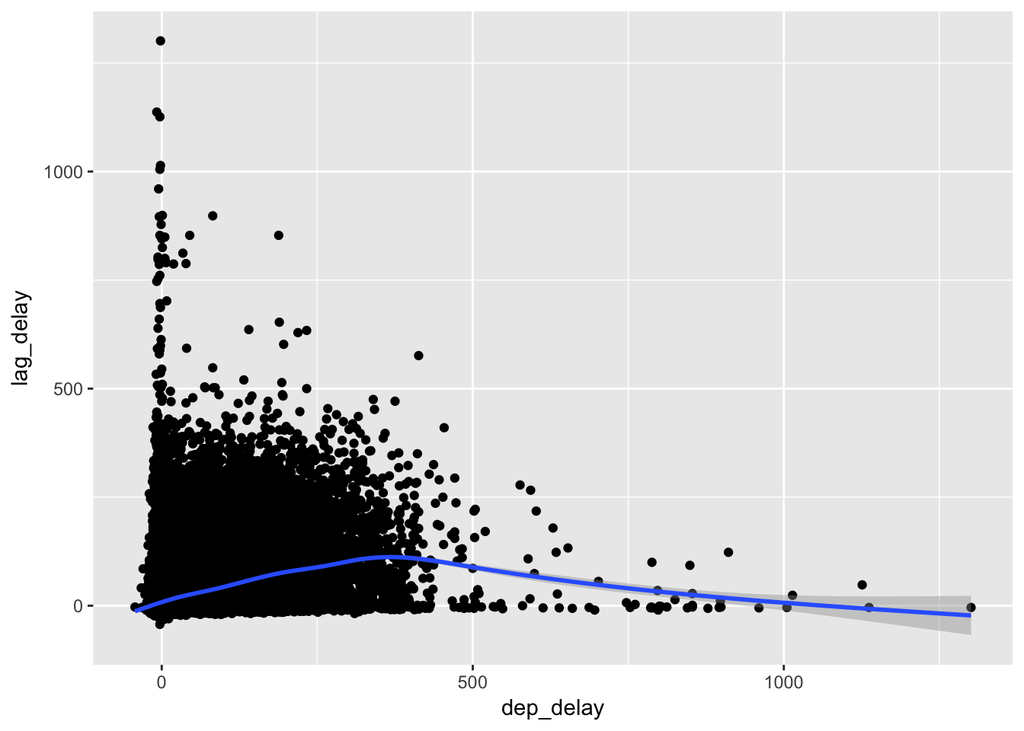

```r
flights %>%
  group_by(year, month, day) %>%
  mutate(lag_delay = lag(dep_delay)) %>%
  ggplot(aes(x = dep_delay, y = lag_delay)) +
    geom_point() +
    geom_smooth()
```

6. Look at each destination. Can you find flights that are suspiciously fast? (i.e. flights that represent a potential data entry error). Compute the air time a flight relative to the shortest flight to that destination. Which flights were most delayed in the air?
7. Find all destinations that are flown by at least two carriers. Use that information to rank the carriers.

```r
flights %>%
  group_by(dest, carrier) %>%
  count(carrier) %>%
  filter(carrier >= 2) %>%
  group_by(carrier) %>%
  count(sort = TRUE)
```

```
## # A tibble: 16 x 2
## # Groups: carrier [16]
##    carrier    nn
##    <chr>   <int>
##  1 EV         61
##  2 9E         49
##  3 UA         47
##  4 B6         42
##  5 DL         40
##  6 MQ         20
##  7 AA         19
##  8 WN         11
##  9 US          6
## 10 OO          5
## 11 VX          5
## 12 FL          3
## 13 YV          3
## 14 AS          1
## 15 F9          1
## 16 HA          1
```

8. For each plane, count the number of flights before the first delay of greater than 1 hour.

```r
flights %>%
  group_by(flight) %>%
  filter(dep_delay <= 60) %>%
  count()
```

```
## # A tibble: 3,810 x 2
## # Groups: flight [3,810]
##    flight     n
##     <int> <int>
##  1      1   678
##  2      2    51
##  3      3   609
##  4      4   378
##  5      5   306
##  6      6   198
##  7      7   210
##  8      8   226
##  9      9   135
## 10     10    51
## # ... with 3,800 more rows
```